# IPD-MA Computer Practical 1

Epidemiology & Big Data

Thomas Debray and Valentijn de Jong

## Introduction

In 2006, Rovers et al. (2006) performed an individual participant data meta-analysis (IPD-MA) of six randomized trials of the effects of antibiotics in children with acute otitis media. Their aim was to identify subgroups of children who would and would not benefit more than others from treatment with antibiotics. The primary outcome as an extended course of acute otitis media (AOM), which was defined as pain, fever, or both at 3-7 days. In this practical, you will re-analyze an artificial version of the IPD-MA from Rovers et al. (2006).

### General aim

Your aim is to estimate the effect of antibiotics in children with AOM, and to assess whether it is modified by age or bilateral acute otitis media. Hereto, you will perform several one-stage and two-stage meta-analysis methods whilst evaluating different assumptions. In this exercise, you will perform the two-stage analysis.

Start by reading the paper by Rovers et al. (2006), which can be accessed here.

### Preparation

This practical was developed using R version 4.0.3. Open RStudio and verify if your installed version is up-to-date:

```r
R.Version()$version.string
```

If the correct version of R is installed, proceed by installing the packages metafor, lme4, and logistf. In recent versions of R, the installation of packages frequently fails when some packages have already been loaded. Therefore, unless you have just booted R, it is best to always restart your R session (ctrl + shift + F10 on Windows, cmd + shift + F10 on Mac, or navigate to Session, then Restart R). Restarting R this way unloads all packages and functions, but retains all data and variables.

```r
install.packages("metafor")
install.packages("lme4")
install.packages("logistf")
```

If you have a more recent version of R, it is possible that aforementioned packages can not (yet) be installed. For this reason, carefully verify if installation was successful. Afterwards, the packages can be loaded as follows:

```r
library("metafor")
library("lme4")
library("logistf")
```

Download the practical dataset `AOM.Rdata` and open it in `R`:

```r
load(choose.files())
```

The practical dataset contains a table with information on 1643 children aged from 6 months to 12 years. Explore the data.

```r
summary(ds.final)
```

```
##  STUDY       TREAT             AGE             GENDER          BILAT_0
##  1:240   Min.   :0.0000   Min.   : 0.000   Min.   :0.0000   Min.   :0.0000
##  2:232   1st Qu.:0.0000   1st Qu.: 1.506   1st Qu.:0.0000   1st Qu.:0.0000
##  3:121   Median :1.0000   Median : 3.257   Median :1.0000   Median :0.0000
##  4:315   Mean   :0.5033   Mean   : 3.455   Mean   :0.5027   Mean   :0.3408
##  5:512   3rd Qu.:1.0000   3rd Qu.: 5.009   3rd Qu.:1.0000   3rd Qu.:1.0000
##  6:223   Max.   :1.0000   Max.   :12.721   Max.   :1.0000   Max.   :1.0000
##     POUTCOME
##  Min.   :0.0000
##  1st Qu.:0.0000
##  Median :0.0000
##  Mean   :0.3049
##  3rd Qu.:1.0000
##  Max.   :1.0000
```

An overview of the variables is given below:

- **STUDY** - Trial identification number (1 to 6)
- **TREAT** - Treatment indicator (1 = antibiotics; 0 = placebo)
- **AGE** - Age (years)
- **GENDER** - Gender
- **BILAT_0** - Presence of bilateral acute otitis media (AOM)
- **POUTCOME** - Primary outcome (1 = an extended course of acute otitis media, 0 = no extended course of AOM)

You can also summarize particular subgroups of patients.

**Question 1.** For instance, go ahead and summarize the active and control treatment group of trial 1.

```r
summary(ds.final[ds.final$STUDY==1 & ds.final$TREAT==0,])
```

```
##  STUDY       TREAT        AGE              GENDER          BILAT_0
##  1:126   Min.   :0   Min.   :0.02964   Min.   :0.0000   Min.   :0.0000
##  2:  0   1st Qu.:0   1st Qu.:0.90812   1st Qu.:0.0000   1st Qu.:0.0000
##  3:  0   Median :0   Median :1.17040   Median :1.0000   Median :1.0000
##  4:  0   Mean   :0   Mean   :1.20662   Mean   :0.5317   Mean   :0.6111
##  5:  0   3rd Qu.:0   3rd Qu.:1.51391   3rd Qu.:1.0000   3rd Qu.:1.0000
##  6:  0   Max.   :0   Max.   :2.16463   Max.   :1.0000   Max.   :1.0000
##     POUTCOME
##  Min.   :0.0000
##  1st Qu.:0.0000
##  Median :0.0000
##  Mean   :0.4841
##  3rd Qu.:1.0000
##  Max.   :1.0000
```

```r
summary(ds.final[ds.final$STUDY==1 & ds.final$TREAT==1,])
```

```
##  STUDY       TREAT        AGE             GENDER          BILAT_0
##  1:114   Min.   :1   Min.   :0.2374   Min.   :0.0000   Min.   :0.0000
##  2:  0   1st Qu.:1   1st Qu.:0.9444   1st Qu.:0.0000   1st Qu.:0.0000
##  3:  0   Median :1   Median :1.1969   Median :1.0000   Median :1.0000
##  4:  0   Mean   :1   Mean   :1.2018   Mean   :0.5877   Mean   :0.5526
##  5:  0   3rd Qu.:1   3rd Qu.:1.4581   3rd Qu.:1.0000   3rd Qu.:1.0000
##  6:  0   Max.   :1   Max.   :2.5332   Max.   :1.0000   Max.   :1.0000
##     POUTCOME
##  Min.   :0.0000
##  1st Qu.:0.0000
##  Median :0.0000
##  Mean   :0.3596
##  3rd Qu.:1.0000
##  Max.   :1.0000
```

**Question 2.** Explore the baseline characteristics of each trial. Do you think participant characteristics are sufficiently balanced across the treatment arms?

| Study | Treatment | Mean Age | SD Age | Female gender | Bilateral AOM |
| --- | --- | --- | --- | --- | --- |
| 1 | 0 | 1.206620 | 0.4143196 | 53% | 61% |
| 1 | 1 | 1.201795 | 0.4024765 | 59% | 55% |
| 2 | 0 | 5.550011 | 1.9341343 | 50% | 25% |
| 2 | 1 | 5.124738 | 1.8108771 | 49% | 9% |
| 3 | 0 | 3.964858 | 1.9288525 | 38% | 21% |
| 3 | 1 | 3.817615 | 1.8796100 | 41% | 19% |
| 4 | 0 | 4.668441 | 2.3608246 | 48% | 23% |
| 4 | 1 | 5.173856 | 2.4319378 | 47% | 23% |
| 5 | 0 | 2.855711 | 1.4852713 | 52% | 34% |
| 5 | 1 | 3.104505 | 1.5785878 | 53% | 36% |
| 6 | 0 | 2.765726 | 2.1983722 | 48% | 47% |
| 6 | 1 | 2.672826 | 2.3721019 | 52% | 49% |

**Question 3.** Do you think participant characteristics are sufficiently balanced across the different trials?

**Question 4.** What measures of association can be used to quantify the comparative treatment effect of antibiotics? Describe their interpretation and (dis)advantages.

*Answer: Common measures of association are the odds ratio, the relative risk, and the risk difference.*

Here, we will adopt a log-binomial model to estimate a relative risk (RR) in each trial:

$$\begin{aligned}
\Pr(Y_i=1) &\sim \mathrm{Bernoulli}(p_i) \\ \log(p_i) &= a + b\, x_i
\end{aligned}$$

where $Y_i$ indicates the observed outcome for subject *i*, and where $x_i=1$ for subjects receiving antibiotics and zero otherwise. In `R`, we have:

```r
fit.unadj1 <- glm(POUTCOME ~ TREAT, data = ds.final,
                  family = binomial(link="log"), subset = STUDY==1)
fit.unadj1
```

```
##
## Call:  glm(formula = POUTCOME ~ TREAT, family = binomial(link = "log"),
##     data = ds.final, subset = STUDY == 1)
##
## Coefficients:
## (Intercept)        TREAT
##     -0.7254      -0.2972
##
## Degrees of Freedom: 239 Total (i.e. Null);  238 Residual
## Null Deviance:       327.3
## Residual Deviance: 323.5     AIC: 327.5
```

**Question 5.** Compute the relative risk for antibiotics treatment.

The relative risk for antibiotics treatment can be obtained by taking the exponent of the regression coefficient for `TREAT`:

```r
exp(coefficients(fit.unadj1)["TREAT"])
```

```
##     TREAT
## 0.7428818
```

```r
exp(confint(fit.unadj1, "TREAT"))
```

```
##     2.5 %    97.5 %
## 0.5422254 1.0011782
```

**Question 6.** We can also calculate an adjusted treatment effect for trial 1. How would you do this?

```r
fit.adj1 <- glm(POUTCOME ~ TREAT + AGE + GENDER + BILAT_0,
                data = ds.final,
                family = binomial(link = "log"),
                subset = STUDY==1)
exp(c(coefficients(fit.adj1)["TREAT"], confint(fit.adj1, "TREAT")))
```

```
##     TREAT     2.5 %    97.5 %
## 0.7599513 0.5544375 1.0235627
```

## Two-stage meta-analysis

### Investigating overall treatment effect

We will start by summarizing the overall treatment effect of antibiotics. In a two-stage meta-analysis, each trial is first analysed in separation, using an appropriate statistical model. Here, we will use the log-binomial model to estimate an (adjusted) relative risk in each trial. We store the estimated regression coefficients and standard errors in the data frame `ad.results`:

```r
studies <- sort(unique(ds.final$STUDY))
ad.results <- data.frame(logRR=NULL, logRR.se=NULL)

for (i in 1:length(studies)) {
  fit <- glm(POUTCOME ~ TREAT + AGE + GENDER + BILAT_0,
             data = ds.final,
             family = binomial(link="log"),
             subset = STUDY==studies[i])
  ad.results[i, "logRR"] <- coefficients(fit)["TREAT"]
  ad.results[i, "logRR.se"] <- sqrt(vcov(fit)["TREAT","TREAT"])
}

ad.results
```

```
##         logRR  logRR.se
## 1 -0.27450095 0.1539032
## 2 -0.03517985 0.2390900
## 3 -1.02386565 0.4818588
## 4 -0.80247648 0.1962689
## 5 -0.44270592 0.1371474
## 6 -0.59830150 0.1981066
```

We can create a plot summarizing the different treatment effects:

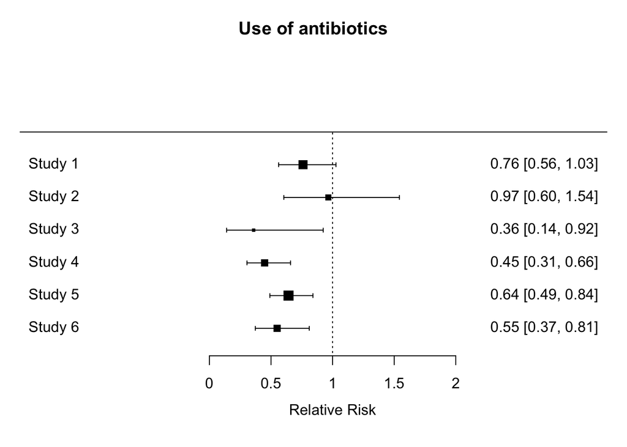

```r
with(ad.results, forest(x = logRR, sei = logRR.se,
                        transf = exp, refline = 1,
                        xlab = "Relative Risk",
                        main = "Use of antibiotics"))
```

**Question 7.** How do we call the figures generated by the forest function? What do they depict?

*Answer: They are called forest plots. Each square is the point estimate from a single study, surrounded by its confidence interval.*

**Question 8.** What can you tell about the treatment effect of antibiotics? Do you think there is between-study heterogeneity? What is the (approximate) average RR across the included studies?

#### Fixed effect meta-analysis

Meta-analysis is an option when the identified studies are considered sufficiently robust and comparable, and requires there are at least two estimates of the same statistic across studies. In a fixed effect meta-analysis, each study estimate $\hat b_i$ (e.g. log RR) is weighted by its precision to derive a pooled effect estimate. More generally, we have:

$$\hat b_i \sim \mathcal{N}\left(\mu, \left(\mathrm{SE}(\hat b_i)\right)^2\right)$$

The summary effect is then given by $\mu$. We can implement this model in `R` as follows:

```r
fe.2stage <- rma(yi = logRR, sei = logRR.se, method = "FE", data = ad.results)
summary(fe.2stage)
```

```
##
## Fixed-Effects Model (k = 6)
##
##   logLik  deviance       AIC       BIC      AICc
##  -1.0056    9.5166    4.0111    3.8029    5.0111
##
## I^2 (total heterogeneity / total variability):   47.46%
## H^2 (total variability / sampling variability):  1.90
##
## Test for Heterogeneity:
## Q(df = 5) = 9.5166, p-val = 0.0901
##
## Model Results:
##
## estimate      se     zval    pval    ci.lb    ci.ub
##  -0.4521  0.0770  -5.8702  <.0001  -0.6030  -0.3011  ***
##
## ---
## Signif. codes:  0 '***' 0.001 '**' 0.01 '*' 0.05 '.' 0.1 ' ' 1
```

**Question 9.** What is the summary estimate for the RR? Extract the 95% confidence interval.

*Answer: The summary estimate for the RR is exp(-0.452). The 95% confidence interval ranges from exp(-0.452 - 1.96 x 0.077) to exp(-0.452 + 1.96 x 0.077).*

You should obtain the following results:

```r
exp(c("RR" = as.numeric(coef(fe.2stage)),
      "2.5 %" = (predict(fe.2stage))$ci.lb,
      "97.5 %" = (predict(fe.2stage))$ci.ub))
```

```
##        RR     2.5 %    97.5 %
## 0.6363188 0.5471730 0.7399882
```

Use of a fixed effect meta-analysis model assumes all studies are estimating the same (common) treatment effect. In other words, there is no between study heterogeneity in the true treatment effect. The implication of this model is that the observed treatment effect estimates vary only because of chance differences created from sampling patients. Hypothetically, if all studies had an infinite sample size, there would be no differences due to chance and the differences in study estimates would completely disappear (Riley, Higgins, and Deeks 2011).

#### Random effects meta-analysis

A random-effects meta-analysis model assumes the observed estimates of treatment effect can vary across studies because of real differences in the treatment effect in each study as well as sampling variability (chance). Thus, even if all studies had an infinitely large sample size, the observed study effects would still vary because of the real differences in treatment effects. Such heterogeneity in treatment effects is caused by differences in study populations (such as age of patients), interventions received (such as dose of drug), follow-up length, and other factors (Riley, Higgins, and Deeks 2011). A random effects approach is therefore often essential to allow for unexplained heterogeneity across studies:

$$\begin{aligned}
\hat b_i &\sim \mathcal{N}\left(b_i, \left(\mathrm{SE}(\hat b_i)\right)^2\right) \\
b_i &\sim \mathcal{N}\left(\mu, \tau^2\right)
\end{aligned}$$

The average effect $\mu$ is now allowed vary across studies, with a (between-study) standard deviation of $\tau$. We can estimate the corresponding model using Restricted Maximum Likelihood Estimation:

```r
re.2stage <- rma(yi = logRR, sei = logRR.se, method = "REML", data = ad.results)
summary(re.2stage)
```

```
##
## Random-Effects Model (k = 6; tau^2 estimator: REML)
##
##   logLik  deviance       AIC       BIC      AICc
##  -1.3302    2.6604    6.6604    5.8793   12.6604
##
## tau^2 (estimated amount of total heterogeneity): 0.0329 (SE = 0.0458)
## tau (square root of estimated tau^2 value):      0.1813
## I^2 (total heterogeneity / total variability):   46.38%
## H^2 (total variability / sampling variability):  1.87
##
## Test for Heterogeneity:
## Q(df = 5) = 9.5166, p-val = 0.0901
##
## Model Results:
##
## estimate      se     zval    pval    ci.lb    ci.ub
##  -0.4664  0.1120  -4.1653  <.0001  -0.6858  -0.2469  ***
##
## ---
## Signif. codes:  0 '***' 0.001 '**' 0.01 '*' 0.05 '.' 0.1 ' ' 1
```

**Question 10.** What is the summary estimate for the RR of antibiotic treatment? Extract the 95% confidence interval, and discuss whether antibiotic treatment is effective.

```r
exp(c("RR" = as.numeric(coef(re.2stage)),
      "2.5 %" = (predict(re.2stage))$ci.lb,
      "97.5 %" = (predict(re.2stage))$ci.ub))
```

```
##        RR     2.5 %    97.5 %
## 0.6272639 0.5036655 0.7811930
```

**Question 11.** Adjust the random effects model to account for uncertainty in the between-study heterogeneity. You can do this by adopting the Sidik-Jonkman Hartung-Knapp correction by specifying the argument `test = "knha"`.

```r
re.2stage.knha <- rma(yi = logRR, sei = logRR.se, method = "REML", test = "knha",
                      data = ad.results)
summary(re.2stage.knha)
```

```
##
## Random-Effects Model (k = 6; tau^2 estimator: REML)
##
##   logLik  deviance       AIC       BIC      AICc
##  -1.3302    2.6604    6.6604    5.8793   12.6604
##
## tau^2 (estimated amount of total heterogeneity): 0.0329 (SE = 0.0458)
## tau (square root of estimated tau^2 value):      0.1813
## I^2 (total heterogeneity / total variability):   46.38%
## H^2 (total variability / sampling variability):  1.87
##
## Test for Heterogeneity:
## Q(df = 5) = 9.5166, p-val = 0.0901
##
## Model Results:
##
## estimate      se     tval    pval    ci.lb    ci.ub
##  -0.4664  0.1198  -3.8937  0.0115  -0.7743  -0.1585  *
##
## ---
## Signif. codes:  0 '***' 0.001 '**' 0.01 '*' 0.05 '.' 0.1 ' ' 1
```

The Sidik-Jonkman Hartung-Knapp correction is an adjustment to the standard error of $\hat \mu$, which helps to account for the uncertainty in the estimate of $\tau$. Confidence intervals are then based on a Student-t distribution with $k-1$ degrees of freedom (where $k$ denotes the number of studies in the meta-analysis), rather than a Normal distribution.

```r
exp(c("RR" = as.numeric(coef(re.2stage.knha)),
      "2.5 %" = (predict(re.2stage.knha))$ci.lb,
      "97.5 %" = (predict(re.2stage.knha))$ci.ub))
```

```
##        RR     2.5 %    97.5 %
## 0.6272639 0.4610296 0.8534377
```

**Question 12.** Do you think there is reason to assume statistical heterogeneity? Extract the estimated between-study standard deviation and I2 statistic. What would be possible causes for heterogeneity in the comparative effectiveness of antibiotics between trials?

*Answer: The estimated between-study standard deviation is 0.181 Although the test for heterogeneity is not statistically significant (P = 0.09), the true treatment effect appears to vary substantially across studies (I2 = 46.38%).*

Although the summary result ($\hat \mu$) is usually the main focus of a meta-analysis, this reflects some average across studies and it may be hard to translate to clinical practice when there is large between-study heterogeneity. We can quantify the impact of between-study heterogeneity by constructing a $100(1-\alpha/2)$% prediction interval, which gives the potential true prognostic effect in a new population conditional on the meta-analysis results (Riley, Higgins, and Deeks 2011). An approximate prediction interval (PI) is given as follows:

$$\hat \mu \pm t_{\alpha, N-2} \sqrt{\hat \tau^2 + \hat \sigma^2}$$

where $t_{\alpha, N-2}$ is the $100(1-\alpha/2)$% percentile of the t-distribution for $N-2$ degrees of freedom, $N$ is the number of studies, $\hat \sigma$ is the estimated standard error of $\hat \mu$, and $\hat \tau$ is the estimated between-study standard deviation. In `R`, you can calculate the approximate 95% PI for $\hat \mu$ as follows:

```r
level <- 0.05
crit <- qt(c(level/2, 1-(level/2)), df = (re.2stage.knha$k-2))
mu <- re.2stage.knha$b[[1]]
tau2 <- re.2stage.knha$tau2
sigma2 <- vcov(re.2stage.knha)
mu + crit * c(sqrt(tau2 + sigma2))
```

```
## [1] -1.0698092  0.1370333
```

**Question 13.** Calculate the boundaries of the 95% PI of the summary RR for antibiotics treatment.

```r
exp(mu + crit * c(sqrt(tau2 + sigma2)))
```

```
## [1] 0.343074 1.146866
```

**Question 14.** Discuss whether antibiotic treatment is likely to be effective in new populations.

An overview of the estimated relative treatment effects is given below:

| Method | Baseline Risk | Treatment effect | Relative Risk | 95% CI | 95% PI |
| --- | --- | --- | --- | --- | --- |
| Two-stage meta-analysis | fixed | random | 0.627 | 0.461; 0.853 | 0.343; 1.147 |

### Investigating effect modifiers

In this section we will explore whether the efficacy of antibiotics is modified by `AGE` or `BILAT_0`.

#### Meta-regression

A simple approach to investigate modifiers of treatment effect is meta-regression. This approach can be visualised by plotting the RR for each trial against the proportion of trial participants who had bilateral AOM, or against the mean participant age in each trial. Hereto, we first need to summarize the covariates for each trial:

```r
mean.age <- mean.bilat_0 <- array(NA, dim=length(studies))
for (i in 1:length(studies)) {
  mean.age[i] <- mean(ds.final[ds.final$STUDY==studies[i], "AGE"])
  mean.bilat_0[i] <- mean(ds.final[ds.final$STUDY==studies[i], "BILAT_0"])
}
ad.results <- cbind(ad.results, mean.age, mean.bilat_0)
ad.results
```

```
##         logRR  logRR.se mean.age mean.bilat_0
## 1 -0.27450095 0.1539032 1.204328    0.5833333
## 2 -0.03517985 0.2390900 5.317210    0.1637931
## 3 -1.02386565 0.4818588 3.894279    0.1983471
## 4 -0.80247648 0.1962689 4.918742    0.2285714
## 5 -0.44270592 0.1371474 2.983023    0.3496094
## 6 -0.59830150 0.1981066 2.719901    0.4798206
```

We can now use `rma()` to perform a random effects meta-regression. For instance, we can explore interaction with the prevalence of bilateral AOM in each trial as follows:

```r
remr.bilat0 <- rma(yi = logRR, sei = logRR.se, mods = mean.bilat_0,
                   method = "REML", test = "knha", data = ad.results)
summary(remr.bilat0)
```

```
##
## Mixed-Effects Model (k = 6; tau^2 estimator: REML)
##
##   logLik  deviance       AIC       BIC      AICc
##  -1.5588    3.1176    9.1176    7.2764   33.1176
##
## tau^2 (estimated amount of residual heterogeneity):     0.0548 (SE = 0.0699)
## tau (square root of estimated tau^2 value):             0.2342
## I^2 (residual heterogeneity / unaccounted variability): 57.96%
## H^2 (unaccounted variability / sampling variability):   2.38
## R^2 (amount of heterogeneity accounted for):            0.00%
##
## Test for Residual Heterogeneity:
## QE(df = 4) = 8.9832, p-val = 0.0615
##
## Test of Moderators (coefficient 2):
## F(df1 = 1, df2 = 4) = 0.1050, p-val = 0.7622
##
## Model Results:
##
##          estimate      se     tval    pval    ci.lb   ci.ub
## intrcpt   -0.5773  0.3530  -1.6356  0.1773  -1.5572  0.4027
## mods       0.2894  0.8933   0.3240  0.7622  -2.1909  2.7697
##
## ---
## Signif. codes:  0 '***' 0.001 '**' 0.01 '*' 0.05 '.' 0.1 ' ' 1
```

The presence of trial-level interaction is captured by the regression coefficient for `mean.bilat_0` (possibly labeled as `mods`).

**Question 15.** Is there any evidence of effect modification? Motivate your answer. What does the intercept term of the meta-regression model represent?

*Answer: The regression coefficient for the proportion of bilateral AOM in a trial is 0.289 (P = 0.762). Adjusting for the prevalence of bilateral AOM did not help to explain the presence of between-study heterogeneity (R2 = 0.00%). The intercept term indicates the summary log RR for a population with a zero prevalence of bilateral AOM.*

An overview is given below:

| Method | Approach | Interaction Effect | P value |
| --- | --- | --- | --- |
| Meta-regression | 2-stage | 0.2894343 | 0.7621782 |

We can visualize the results of a meta-regression by constructing a scatterplot.

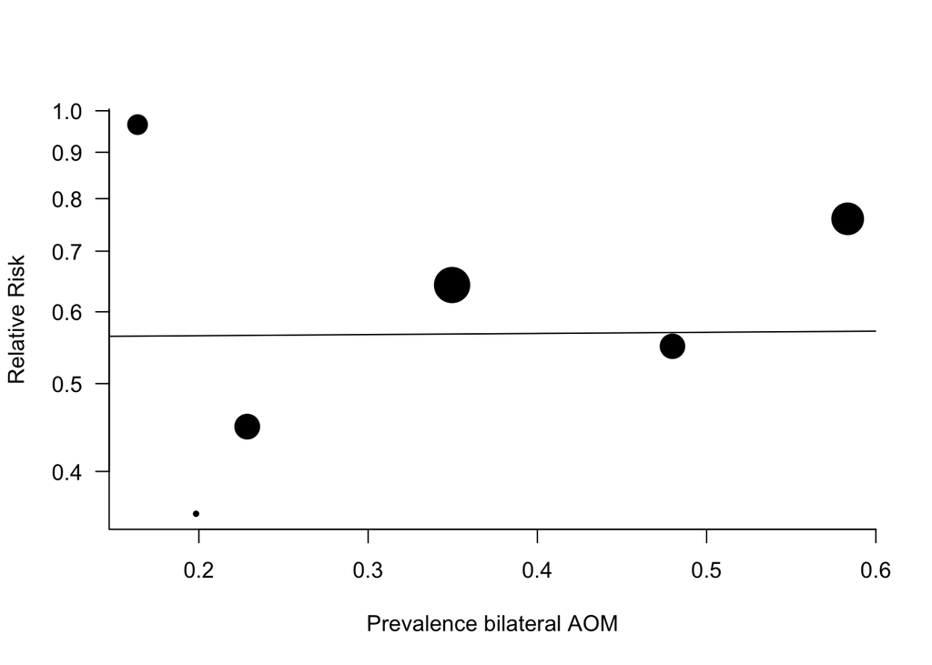

```r
### calculate predicted RR for mean participant age 0 to 100
preds <- predict(remr.bilat0, newmods=seq(0, 1, 0.01), transf=exp)

### calculate point sizes by rescaling the standard errors
wi    <- 1/sqrt(ad.results$logRR.se)
size  <- 0.5 + 3.0 * (wi - min(wi))/(max(wi) - min(wi))

### plot the RR against mean participant age
plot(ad.results$mean.bilat_0, exp(ad.results$logRR), pch=19, cex=size,
     xlab="Prevalence bilateral AOM", ylab="Relative Risk",
     las=1, bty="l", log="y")

### add predicted values (and corresponding CI bounds)
lines(seq(0, 10, 0.1), preds$pred)
lines(seq(0, 10, 0.1), preds$ci.lb, lty="dashed")
lines(seq(0, 10, 0.1), preds$ci.ub, lty="dashed")
```

#### Pooling of within-trial covariate interactions

We will now perform pooling of within-trial covariate interactions as an alternative (and statistically more valid) approach to investigate treatment-covariate interaction. For sake of time, we will focus on the presence of bilateral AOM from here onwards.

**Question 16.** Adjust the statistical model for investigating overall treatment effect to include an interaction effect for your chosen covariate (i.e. `AGE` or `BILAT_0`). The relevant commands for this are given below.

```r
ad2.results <- data.frame(logRR = NULL, logRR.se = NULL,
                          beta.int = NULL, beta.int.se = NULL)

for (i in 1:length(studies)) {
  fit <- glm(POUTCOME ~ TREAT + AGE + GENDER + BILAT_0 + TREAT:BILAT_0,
             data = ds.final,
             family = binomial(link="log"),
             subset = STUDY==studies[i])
  ad2.results[i, "logRR"] <- coefficients(fit)["TREAT"]
  ad2.results[i, "logRR.se"] <- sqrt(vcov(fit)["TREAT","TREAT"])
  ad2.results[i, "beta.int"] <- coefficients(fit)["TREAT:BILAT_0"]
  ad2.results[i, "beta.int.se"] <- sqrt(vcov(fit)["TREAT:BILAT_0","TREAT:BILAT_0"])
}

ad2.results
```

```
##        logRR  logRR.se     beta.int  beta.int.se
## 1  0.1277884 0.2406854  -0.68747132    0.3219244
## 2  0.2399833 0.2773777  -1.81877128    1.0275741
## 3 -0.7404458 0.4998488 -16.43628615 1786.0171852
## 4 -0.7861593 0.2148514  -0.09497905    0.5234250
## 5 -0.3338054 0.1833771  -0.24057028    0.2758637
## 6 -0.4377321 0.2578996  -0.37401117    0.4065961
```

Note that the regression coefficient and standard error for the treatment-covariate interaction term could not properly be estimated in trial 3. This problem is related to the relatively small sample size, and has important implications for meta-analysis. To avoid that trial 3 will be ignored during meta-analysis (due to the large SE), we will apply Firth’s correction (see [Firth’s article](https://www.jstor.org/stable/2336755?seq=1) (Firth 1993), and [the application to logistic regression](https://doi.org/10.1002/sim.1047) (Heinze and Schemper 2002)). This approach applies a correction to the maximum likelihood estimation procedure to correct for small sample bias. Its estimates also tend to have smaller standard errors. Therefore, it generally has more power and its use is recommended whenever you are trying to estimate a therapeutic or aetiological effect in a small or medium sized data set.

```r
library(logistf)

ds.study3 <- subset(ds.final, STUDY==studies[3])
fit <- logistf(POUTCOME ~ TREAT + AGE + GENDER + BILAT_0 + TREAT:BILAT_0,
               data = ds.study3)
index1 <- which(names(coefficients(fit))=="TREAT")
index2 <- which(names(coefficients(fit))=="TREAT:BILAT_0")

ad2.results[3, "logRR"] <- coefficients(fit)[index1]
ad2.results[3, "logRR.se"] <- sqrt(vcov(fit)[index1, index1])
ad2.results[3, "beta.int"] <- coefficients(fit)[index2]
ad2.results[3, "beta.int.se"] <- sqrt(vcov(fit)[index2, index2])
ad2.results
```

```
##        logRR  logRR.se    beta.int beta.int.se
## 1  0.1277884 0.2406854 -0.68747132   0.3219244
## 2  0.2399833 0.2773777 -1.81877128   1.0275741
## 3 -0.8443522 0.5678976 -1.45699186   1.6993663
## 4 -0.7861593 0.2148514 -0.09497905   0.5234250
## 5 -0.3338054 0.1833771 -0.24057028   0.2758637
## 6 -0.4377321 0.2578996 -0.37401117   0.4065961
```

**Bonus question.** Apply Firth regression to all trials, and update the corresponding estimates in `ad2.results`.

The presence of treatment-covariate interaction is captured by the regression coefficient for `beta.int`. We can now summarize these estimates using a random effects meta-analysis:

```r
repwt.bilat0  <- rma(yi = beta.int, sei = beta.int.se,
                     method = "REML",
                     test="knha",
                     data = ad2.results)
summary(repwt.bilat0)
```

```
##
## Random-Effects Model (k = 6; tau^2 estimator: REML)
##
##   logLik  deviance       AIC       BIC      AICc
##  -3.9133    7.8266   11.8266   11.0455   17.8266
##
## tau^2 (estimated amount of total heterogeneity): 0 (SE = 0.0997)
## tau (square root of estimated tau^2 value):      0
## I^2 (total heterogeneity / total variability):   0.00%
## H^2 (total variability / sampling variability):  1.00
##
## Test for Heterogeneity:
## Q(df = 5) = 3.7313, p-val = 0.5887
##
## Model Results:
##
## estimate      se     tval    pval    ci.lb    ci.ub
##  -0.4331  0.1486  -2.9139  0.0332  -0.8152  -0.0510  *
##
## ---
## Signif. codes:  0 '***' 0.001 '**' 0.01 '*' 0.05 '.' 0.1 ' ' 1
```

**Question 17.** Is there any evidence of effect modification? Motivate your answer.

*Answer: The summary estimate for the treatment-covariate interaction is -0.433 (P = 0.033). There is statistical evidence that the presence of bilateral AOM increases the efficacy of antibiotics treatment.*

An overview is given below:

| Method | Approach | Interaction Effect | P value |
| --- | --- | --- | --- |
| Meta-regression | 2-stage | 0.2894343 | 0.7621782 |
| Pooling of within-trial covariate interactions | 2-stage | -0.4330957 | 0.0332469 |

## References

Firth, David. 1993. “Bias Reduction of Maximum Likelihood Estimates.” *Biometrika*, 27–38.

Heinze, Georg, and Michael Schemper. 2002. “A Solution to the Problem of Separation in Logistic Regression.” *Stat Med* 21 (16): 2409–19. https://doi.org/10.1002/sim.1047.

Riley, R. D., J. P. T. Higgins, and J. J. Deeks. 2011. “Interpretation of Random Effects Meta-Analyses.” *BMJ* 342 (feb10 2): d549–d549. https://doi.org/10.1136/bmj.d549.

Rovers, Maroeska M., Paul Glasziou, Cees L. Appelman, Peter Burke, David P. McCormick, Roger A. Damoiseaux, Isabelle Gaboury, Paul Little, and Arno W. Hoes. 2006. “Antibiotics for Acute Otitis Media: A Meta-Analysis with Individual Patient Data.” *Lancet* 368 (9545): 1429–35. https://doi.org/10.1016/S0140-6736(06)69606-2.